# STAT 413/613 Homework on Web Data: APIs and Scraping

Jaehee Lee

2021-03-30

# Instructions

- Write your solutions **in this starter file**.
  - Modify the “author” field in the YAML header.
- Commit R Markdown and HTML files (no PDF files). **Push both .Rmd and HTML files to GitHub**.
  - Make sure you have knitted to HTML for your final submission.
- **Only include necessary code and data** to answer the questions.
- Most of the functions you use should be from the tidyverse. **Too much base R** will result in point deductions.
- Submit a response on Canvas that your assignment is complete on GitHub
- Feel free to use Pull requests and or email (attach your .Rmd) to ask me any questions.

# 1 IMDB List of Oscar Winners

IMDB has a list of the [Oscar Best Picture Winners](https://www.imdb.com/search/title/?count=100&groups=oscar_best_picture_winners&sort=year%2Cdesc&ref_=nv_ch_osc).

Scrape the following elements, convert the data into a tibble, tidy it, and clean it to answer the questions below:

- Number
- Title
- Year
- MPAA Rating
- Length in minutes
- Genre
- Star Rating
- Metascore Rating
- Gross Receipts

Convert the data into a tibble, tidy it, and clean it to answer the following questions:

```r
# load packages
library(rvest)
library(tidyverse)
library(stringr)
```

## 1.1 Use read_html() to save an HTML file to a variable.

```r
# html_obj <- read_html("https://www.imdb.com/search/title/?count=100&groups=oscar_best_picture_winners&sort=year%2Cdesc&ref_=nv_ch_osc")
# html_obj
# class(html_obj)

# I used below html url because I am in South Korea and when I use the above url, some of the data are translated and some of them appear different, so I figured out using cache.

html_obj_1 <- read_html("https://webcache.googleusercontent.com/search?q=cache:fvpH0ObPBr0J:https://www.imdb.com/search/title/%3Fcount%3D100%26groups%3Doscar_best_picture_winners%26sort%3Dyear%252Cdesc%26ref_%3Dnv_ch_osc+&cd=1&hl=ko&ct=clnk&gl=kr")
class(html_obj_1)
```

```
## [1] "xml_document" "xml_node"
```

```r
Data <- html_nodes(html_obj_1,
                              css = ".ghost~ .text-muted+ span , .genre , .runtime ,
.certificate , strong , .favorable , .unbold , .lister-item-header a")

Data_text <- html_text(Data)
```

```r
datadf <- tibble(text = Data_text)

datadf %>%
  mutate(ismovierank = str_detect(text, "^\\d+\\.$")) -> datadf

datadf %>%
  mutate(movienum = cumsum(ismovierank)) %>%
  filter(movienum > 0) -> datadf

datadf %>%
  mutate(isyear = str_detect(text, "\\(\\d{4}\\)")) -> datadf

datadf %>%
  mutate(isgenre = str_detect(text, "^\\n")) -> datadf

datadf %>%
  mutate(isStarRating = str_detect(text, "^\\d+\\.+\\d$")) -> datadf

datadf %>%
  mutate(isGross_Receipts = str_detect(text, "^\\$")) -> datadf

data0 <- html_nodes(html_obj_1, ".lister-item-header a")
data0_text <- html_text(data0)
datadf %>%
  mutate(isname = text %in% data0_text) -> datadf

datadf %>%
  mutate(islength = str_detect(text,"^\\d{1,3}+\\s+min$")) -> datadf

datadf %>%
  mutate(isMetascore_Rating = str_detect(text, "^\\d{1,3}+\\s+$")) -> datadf

datadf %>%
  mutate(isMPAA = !ismovierank & !isyear & !isgenre & !isStarRating & !isGross_Receipts & !isname &!isMetascore_Rating &!islength) ->datadf
head(datadf)
```

```
## # A tibble: 6 x 11
##   text  ismovierank movienum isyear isgenre isStarRating isGross_Receipts isname
##   <chr> <lgl>          <int> <lgl>  <lgl>   <lgl>        <lgl>            <lgl>
## 1 "1."  TRUE               1 FALSE  FALSE   FALSE        FALSE            FALSE
## 2 "Par… FALSE              1 FALSE  FALSE   FALSE        FALSE            TRUE
## 3 "(20… FALSE              1 TRUE   FALSE   FALSE        FALSE            FALSE
## 4 "R"   FALSE              1 FALSE  FALSE   FALSE        FALSE            FALSE
## 5 "132… FALSE              1 FALSE  FALSE   FALSE        FALSE            FALSE
## 6 "\nC… FALSE              1 FALSE  TRUE    FALSE        FALSE            FALSE
## # … with 3 more variables: islength <lgl>, isMetascore_Rating <lgl>,
## #   isMPAA <lgl>
```

```r
## make sure we have 93 movies:
sum(datadf$isname)
```

```
## [1] 93
```

```r
datadf %>%
  mutate(key = case_when(ismovierank ~ "rank",
                         isyear ~ "year",
                         isgenre ~ "genre",
                        islength ~ "length",
                         isMetascore_Rating ~ "metacritic",
                         isGross_Receipts ~ "gross_receipts",
                         isStarRating ~ "star_rating",
                        isMPAA ~ "MPAA",
                        isname ~ "name")) %>%
  select(key, text, movienum) %>%
  pivot_wider(names_from = key, values_from = text) -> datawide
head(datawide)
```

```
## # A tibble: 6 x 10
##   movienum rank  name       year   MPAA  length genre     star_rating metacritic
##      <int> <chr> <chr>      <chr>  <chr> <chr>  <chr>     <chr>       <chr>
## 1        1 1.    Parasite   (2019) R     132 m… "\nComed… 8.6         "96      …
## 2        2 2.    Green Book (2018) PG-13 130 m… "\nBiogr… 8.2         "69      …
## 3        3 3.    The Shape… (2017) R     123 m… "\nAdven… 7.3         "87      …
## 4        4 4.    Moonlight  (I) (… R     111 m… "\nDrama… 7.4         "99      …
## 5        5 5.    Spotlight  (I) (… R     129 m… "\nBiogr… 8.1         "93      …
## 6        6 6.    Birdman o… (2014) R     119 m… "\nComed… 7.7         "87      …
## # … with 1 more variable: gross_receipts <chr>
```

```r
datawide %>%
  mutate(length = str_extract_all(length, "[0-9]+")) %>%
  mutate(year = str_extract_all(year, "[0-9]+")) %>%
  mutate(gross_receipts = str_sub(gross_receipts, 2, -2)) %>%
  mutate(genre = str_replace_all(genre, "\\n", ""),
         genre = str_squish(genre)) %>%
  mutate(movienum=NULL) -> datawide
head(datawide)
```

```
## # A tibble: 6 x 9
##   rank  name     year  MPAA  length genre  star_rating metacritic gross_receipts
##   <chr> <chr>    <lis> <chr> <list> <chr>  <chr>       <chr>      <chr>
## 1 1.    Parasite <chr… R     <chr … Comed… 8.6         "96      … 53.37
## 2 2.    Green B… <chr… PG-13 <chr … Biogr… 8.2         "69      … 85.08
## 3 3.    The Sha… <chr… R     <chr … Adven… 7.3         "87      … 63.86
## 4 4.    Moonlig… <chr… R     <chr … Drama  7.4         "99      … 27.85
## 5 5.    Spotlig… <chr… R     <chr … Biogr… 8.1         "93      … 45.06
## 6 6.    Birdman… <chr… R     <chr … Comed… 7.7         "87      … 42.34
```

```r
# change the datatype
datawide$year <- as.numeric(datawide$year)
datawide$length <- as.numeric(datawide$length)
datawide$star_rating <- as.numeric(datawide$star_rating)
datawide$metacritic <- as.double(datawide$metacritic)
datawide$gross_receipts <- as.numeric(datawide$gross_receipts)
```

```r
# see the summary and str of the data
str(datawide)
```

```
## tibble [93 × 9] (S3: tbl_df/tbl/data.frame)
##  $ rank          : chr [1:93] "1." "2." "3." "4." ...
##  $ name          : chr [1:93] "Parasite" "Green Book" "The Shape of Water" "Moonlight" ...
##  $ year          : num [1:93] 2019 2018 2017 2016 2015 ...
##  $ MPAA          : chr [1:93] "R" "PG-13" "R" "R" ...
##  $ length        : num [1:93] 132 130 123 111 129 119 134 120 100 118 ...
##  $ genre         : chr [1:93] "Comedy, Drama, Thriller" "Biography, Comedy, Drama" "Adventure, Drama, Fantasy" "Drama" ...
##  $ star_rating   : num [1:93] 8.6 8.2 7.3 7.4 8.1 7.7 8.1 7.7 7.9 8 ...
##  $ metacritic    : num [1:93] 96 69 87 99 93 87 96 86 89 88 ...
##  $ gross_receipts: num [1:93] 53.4 85.1 63.9 27.9 45.1 ...
```

```r
summary(datawide)
```

```
##      rank               name                year          MPAA
##  Length:93          Length:93          Min.   :1927   Length:93
##  Class :character   Class :character   1st Qu.:1950   Class :character
##  Mode  :character   Mode  :character   Median :1973   Mode  :character
##                                        Mean   :1973
##                                        3rd Qu.:1996
##                                        Max.   :2019
##
##      length         genre            star_rating      metacritic
##  Min.   : 90.0   Length:93          Min.   :5.700   Min.   : 63.00
##  1st Qu.:118.0   Class :character   1st Qu.:7.500   1st Qu.: 78.75
##  Median :129.0   Mode  :character   Median :7.900   Median : 86.00
##  Mean   :137.7                      Mean   :7.788   Mean   : 84.38
##  3rd Qu.:155.0                      3rd Qu.:8.100   3rd Qu.: 91.00
##  Max.   :238.0                      Max.   :9.200   Max.   :100.00
##                                                     NA's   :17
##  gross_receipts
##  Min.   :  0.01
##  1st Qu.: 24.02
##  Median : 54.58
##  Mean   : 81.71
##  3rd Qu.:110.21
##  Max.   :659.33
##  NA's   :10
```

1. Show a summary of the number of data elements for each movie that are not NA. Which two elements are missing the most from the movies?

```r
# 1 method
datawide %>%
  summarise_all(funs(sum(!is.na(.))))
```

```
## # A tibble: 1 x 9
##    rank  name  year  MPAA length genre star_rating metacritic gross_receipts
##   <int> <int> <int> <int>  <int> <int>       <int>      <int>          <int>
## 1    93    93    93    93     93    93          93         76             83
```

```r
# 2 method
sum(is.na(datawide$rank))
```

```
## [1] 0
```

```r
sum(is.na(datawide$name))
```

```
## [1] 0
```

```r
sum(is.na(datawide$MPAA))
```

```
## [1] 0
```

```r
sum(is.na(datawide$length))
```

```
## [1] 0
```

```r
sum(is.na(datawide$genre))
```

```
## [1] 0
```

```r
sum(is.na(datawide$star_rating))
```

```
## [1] 0
```

```r
sum(is.na(datawide$metacritic))
```

```
## [1] 17
```

```r
sum(is.na(datawide$gross_receipts))
```

```
## [1] 10
```

```r
# The two elements that are missing the most from the movies: metaScore_Rating and gross_receipts
```

2. Create a plot of the length of a film and its gross, color coded by rating. Show linear smoothers for each rating.
- Does MPAA rating matter?

```r
library(ggplot2)
sum(datadf$islength)
```

```
## [1] 93
```

```r
sum(datadf$isGross_Receipts)
```

```
## [1] 83
```

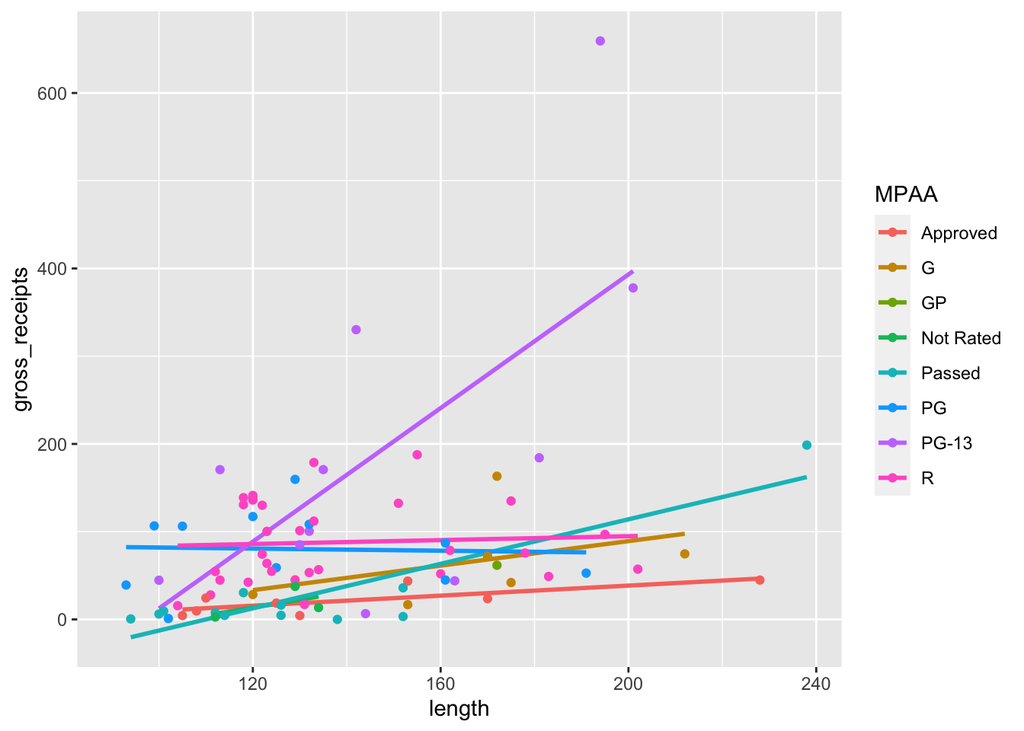

```r
ggplot(data = datawide, aes(x = length, y = gross_receipts, color = MPAA)) +
   geom_smooth(method = "lm", se = FALSE)+
   geom_point()
```

3. Create a plot with a single Ordinary Least Squares smoothing line with no standard errors showing for predicting stars rating based on metacritic scores for those movies that have metacritic scores.
- Use a linear model to assess if there is there a meaningful relationship. Show the summary of the output and interpret in terms of the $p$-value and the adjusted R-Squared?

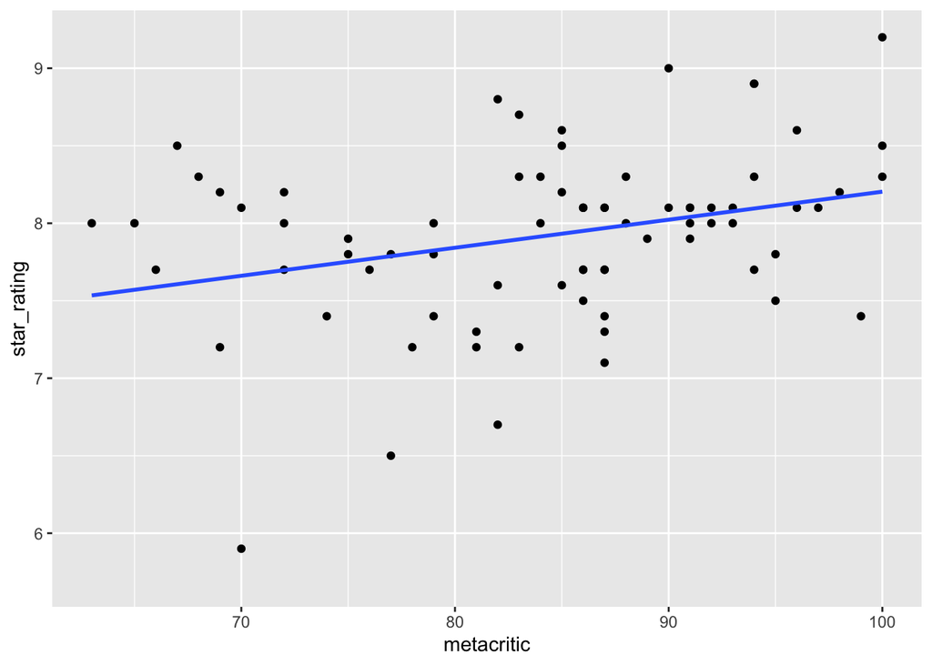

```r
datawide %>%
  ggplot(aes(y = star_rating, x = metacritic)) +
  geom_point() +
  geom_smooth(method = "lm", se = FALSE)
```

```r
data_3 <- lm(metacritic ~ star_rating, data = datawide)
summary(data_3)
```

```
##
## Call:
## lm(formula = metacritic ~ star_rating, data = datawide)
##
## Residuals:
##     Min      1Q  Median      3Q     Max
## -21.787  -4.915   1.686   5.908  17.293
##
## Coefficients:
##             Estimate Std. Error t value Pr(>|t|)
## (Intercept)   43.718     14.811   2.952  0.00423 **
## star_rating    5.134      1.865   2.752  0.00744 **
## ---
## Signif. codes:  0 '***' 0.001 '**' 0.01 '*' 0.05 '.' 0.1 ' ' 1
##
## Residual standard error: 8.924 on 74 degrees of freedom
##   (17 observations deleted due to missingness)
## Multiple R-squared:  0.09285,    Adjusted R-squared:  0.08059
## F-statistic: 7.574 on 1 and 74 DF,  p-value: 0.007443
```

# 2 Interpretation:

p-value is 0.007443 which is smaller than significance level( =0.01),this will reject the null hypothesis and this tells us that this is statistically significant. Adusted R-squared is 0.08059, this means that we can only explain 8% of this model, indicating that this is not a good model. Since Adjusted R2 indicates how well terms fit a curve or line. When we see the graph above, we can easily see that a lot of points do not well align with the blue line. Therefore, I feel this is not a good model: This linear model doesn’t show that there is a meaningful relationship between star_rating and metaScore_rating.

4. Use an appropriate plot to compare the gross receipts by MPAA rating.

```r
str(datawide)
```

```
## tibble [93 × 9] (S3: tbl_df/tbl/data.frame)
##  $ rank          : chr [1:93] "1." "2." "3." "4." ...
##  $ name          : chr [1:93] "Parasite" "Green Book" "The Shape of Water" "Moonlight" ...
##  $ year          : num [1:93] 2019 2018 2017 2016 2015 ...
##  $ MPAA          : chr [1:93] "R" "PG-13" "R" "R" ...
##  $ length        : num [1:93] 132 130 123 111 129 119 134 120 100 118 ...
##  $ genre         : chr [1:93] "Comedy, Drama, Thriller" "Biography, Comedy, Drama" "Adventure, Drama, Fantasy" "Drama" ...
##  $ star_rating   : num [1:93] 8.6 8.2 7.3 7.4 8.1 7.7 8.1 7.7 7.9 8 ...
##  $ metacritic    : num [1:93] 96 69 87 99 93 87 96 86 89 88 ...
##  $ gross_receipts: num [1:93] 53.4 85.1 63.9 27.9 45.1 ...
```

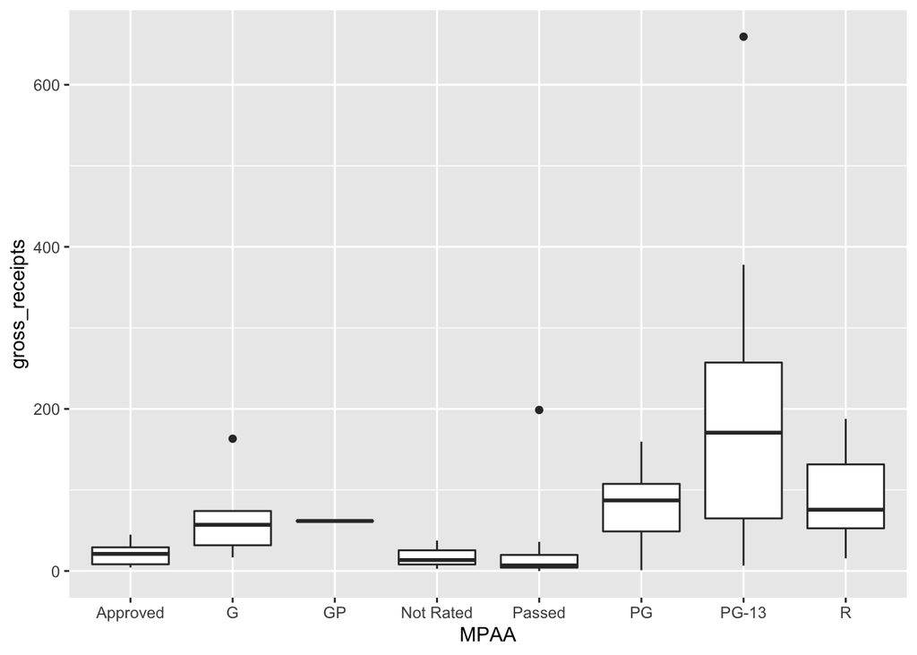

```r
datawide %>%
  group_by(as.factor(MPAA)) %>%
ggplot(aes(y = gross_receipts, x = MPAA)) +
  geom_boxplot()
```

- Which MPAA rating has the highest median gross receipts?

```r
# The black line inside the box is the median. We can see that when MPAA is "PG-13", the median gross_receipts is the highest.
```

- Which R-rated movies are in the overall top 10 of gross receipts?

```r
datawide %>%
  filter(MPAA == "R") %>%
  arrange(desc(gross_receipts)) %>%
  head(10) %>%
  select(name)
```

```
## # A tibble: 10 x 1
##    name
##    <chr>
##  1 Gladiator
##  2 Rain Man
##  3 Slumdog Millionaire
##  4 The King's Speech
##  5 Platoon
##  6 Argo
##  7 The Godfather
##  8 The Departed
##  9 The Silence of the Lambs
## 10 American Beauty
```

- Use one-way analysis of variance to assess the level of evidence for whether all ratings have the same mean gross receipts. Show the summary of the results and provide your interpretation of the results.

```r
# Compute the analysis of variance
one.way <- aov(gross_receipts ~ MPAA, data = datawide)
# Summary of the analysis
summary(one.way)
```

```
##             Df Sum Sq Mean Sq F value   Pr(>F)
## MPAA         7 228480   32640   4.828 0.000158 ***
## Residuals   75 507046    6761
## ---
## Signif. codes:  0 '***' 0.001 '**' 0.01 '*' 0.05 '.' 0.1 ' ' 1
## 10 observations deleted due to missingness
```

# 3 Interpretation: